# Decision trees and Random Forest

Przemyslaw Biecek

Data Mining - Advances

# Introduction

In this document we are going to cover following topics:

- A new dataset - Pima Indians
- Overview of classification trees
- Implementations in R
- Overview of Random Forest
- Implementations in R
- ROC

## Pima Indians

Here we are going to use the `pima` dataset as a blasting site for classification trees. The interesting outcome variable is `test` (1 if patient shows signs of diabetes, 0 means that the test for diabetes was negative). There are 8 interesting dependent variables, let’s start with two promising ones, namely glucose and insulin.

```r
library(faraway)
library(MASS)
library(ggplot2)
head(pima)
```

```
##   pregnant glucose diastolic triceps insulin  bmi diabetes age test
## 1        6     148        72      35       0 33.6    0.627  50    1
## 2        1      85        66      29       0 26.6    0.351  31    0
## 3        8     183        64       0       0 23.3    0.672  32    1
## 4        1      89        66      23      94 28.1    0.167  21    0
## 5        0     137        40      35     168 43.1    2.288  33    1
## 6        5     116        74       0       0 25.6    0.201  30    0
```

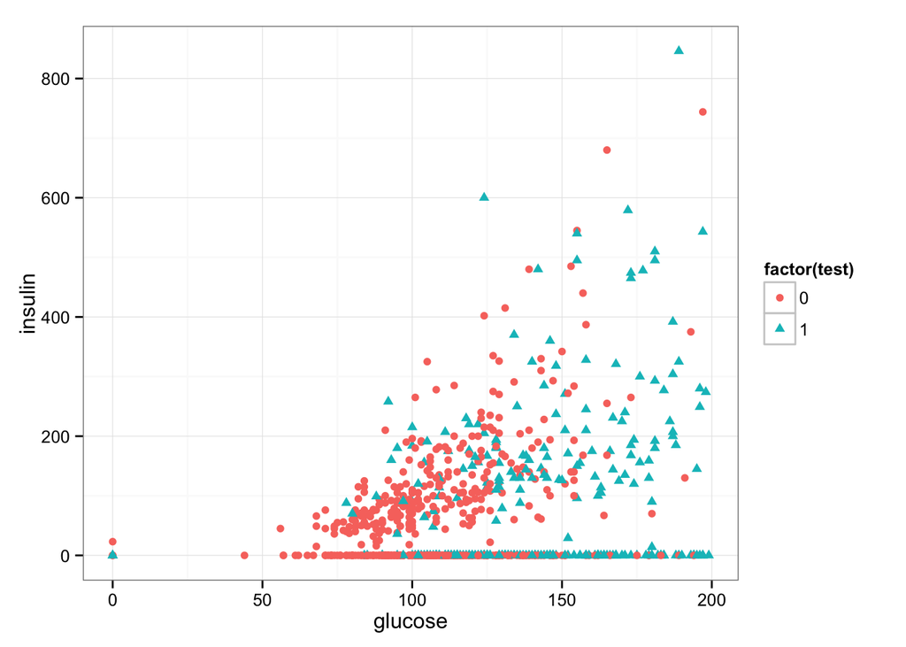

```r
ggplot(pima, aes(glucose, insulin, color=factor(test), shape=factor(test))) +
  geom_point() + theme_bw()
```

And now for all variables.

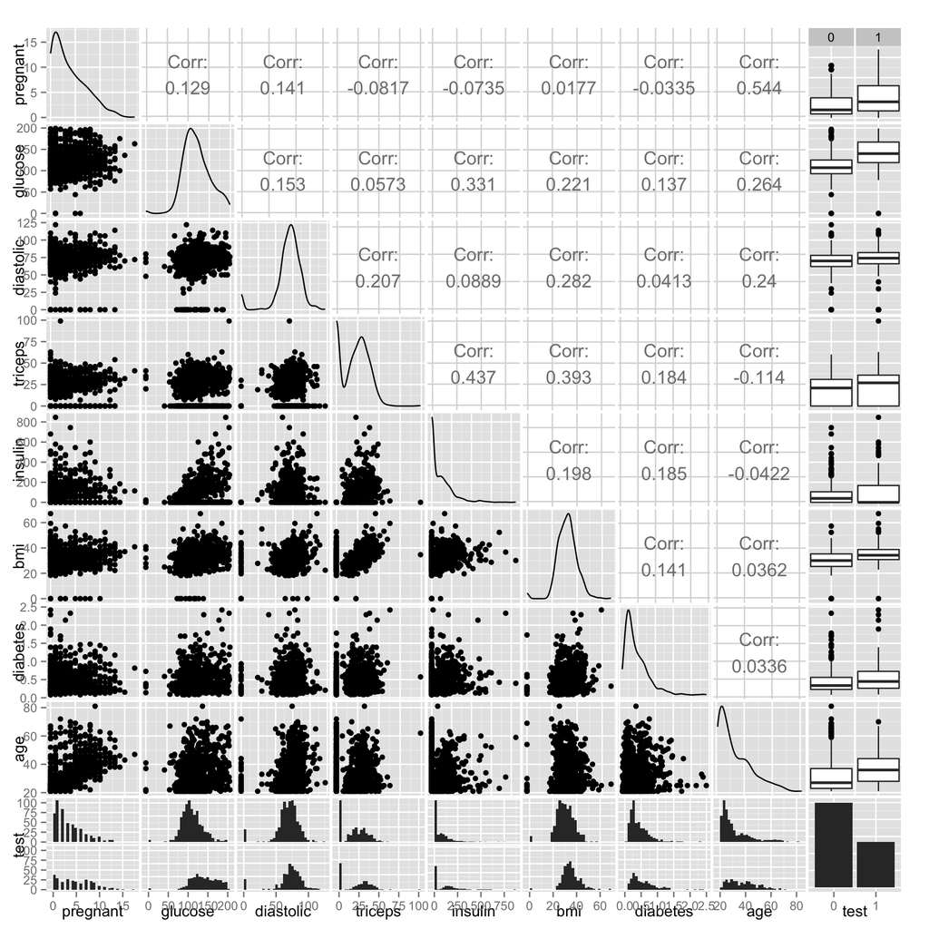

```r
library(GGally)
pima$test <- factor(pima$test)
ggpairs(pima)
```

## Origin of a car

In order to compare results please use the `Cars93` dataset. It has many interesting variables about brands of cars. One can use it to identify cars from USA cars from other countries.

```r
library(party)
head(Cars93)
```

```
##   Manufacturer   Model    Type Min.Price Price Max.Price MPG.city
## 1        Acura Integra   Small      12.9  15.9      18.8       25
## 2        Acura  Legend Midsize      29.2  33.9      38.7       18
## 3         Audi      90 Compact      25.9  29.1      32.3       20
## 4         Audi     100 Midsize      30.8  37.7      44.6       19
## 5          BMW    535i Midsize      23.7  30.0      36.2       22
## 6        Buick Century Midsize      14.2  15.7      17.3       22
##   MPG.highway            AirBags DriveTrain Cylinders EngineSize
## 1          31               None      Front         4        1.8
## 2          25 Driver & Passenger      Front         6        3.2
## 3          26        Driver only      Front         6        2.8
## 4          26 Driver & Passenger      Front         6        2.8
## 5          30        Driver only       Rear         4        3.5
## 6          31        Driver only      Front         4        2.2
##   Horsepower  RPM Rev.per.mile Man.trans.avail Fuel.tank.capacity
```

[output cut: 20 more lines]

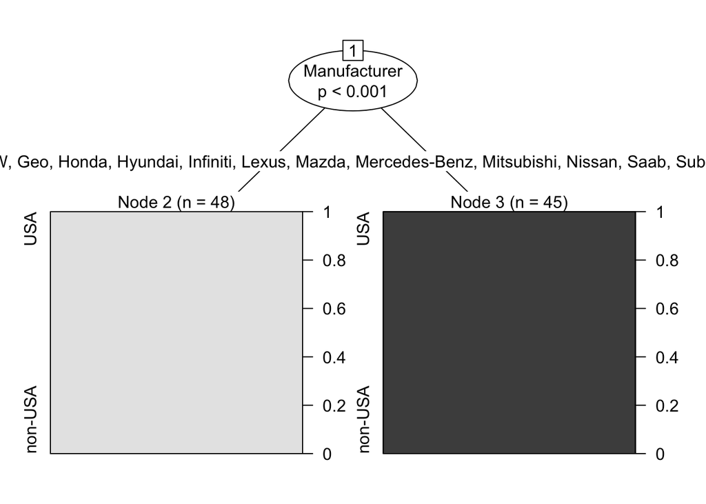

```r
tr <- ctree(Origin~Manufacturer, data=Cars93)
plot(tr)
```

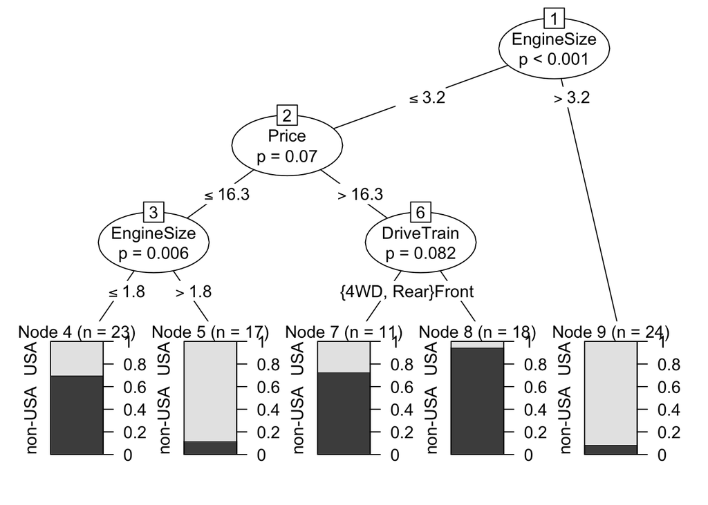

```r
tr <- ctree(Origin~Type+Price+AirBags+DriveTrain+EngineSize, data=Cars93,
  controls=ctree_control(minsplit=0, mincriterion=0.9))
plot(tr)
```

# Overview of decision trees

## Tree structure

Tree is an undirected graph in which any two nodes are connected by exactly one path. Rooted tree has a special node called root. For classification trees variables names are used as node labels for internal nodes. Classes or distributions of classes are used as labels in leaves. Binary conditions correspond for egdes.

## Training of a tree

There are many algorithms for fitting of classification trees. The most popular ones covered and compared in http://www.stat.wisc.edu/~loh/treeprogs/guide/wires11.pdf.

The family of most popular algorithms (C4.5 / CART) are called Top-Down Induction of Decision Trees (TDIDT) and the name comes from the way general scheme for model building. The general algorithm for tree fitting is following:

1. Start with whole training dataset in the root node.
2. For each leaf in the tree find a best split (e.g. by exhaustive search) based on some purity measure (information gain, gain ratio).
3. Verify stopping criteria, if they are not met create two child nodes with subset of the original node (minimum size, maximum depth).
4. Repeat if there are nodes that can be further split.
5. (optionally) Prune back Small trees are better since we believe that the truth is simple (Occam’s Razor).

## Purity measures

- Gini impurity

Used in Classification and regression trees (CART)

$I_G(f) = \sum_{i=1}^m f_i(1-f_i) = 1 - \sum f_i^2$

- Information gain

Used in C4.5

$I_E(f) = - \sum_{i=1}^g f_i \log_2 (f_i)$

Where $f_i$ if the frequency of label $i$ in a given node while $g$ stands for number of groups / classes.

## Predictions

For each observation follow the path from the root to leaves. Examine conditions in nodes.

## Implementations in R

There are many implementations in different packages. Here we are going to cover two most widely used, i.e. implementations from rpart and party.

### The rpart package

Use the `rpart` function to grow a tree. This function handles outcome variable of different classes, use `method="class"` for classification trees.

```r
library(rpart)

rtree <- rpart(test ~ insulin+glucose, data = pima, method="class")
rtree
```

```
## n= 768
##
## node), split, n, loss, yval, (yprob)
##       * denotes terminal node
##
##   1) root 768 268 0 (0.6510417 0.3489583)
##     2) glucose< 127.5 485  94 0 (0.8061856 0.1938144) *
##     3) glucose>=127.5 283 109 1 (0.3851590 0.6148410)
##       6) glucose< 154.5 161  76 0 (0.5279503 0.4720497)
##        12) glucose>=152.5 8   1 0 (0.8750000 0.1250000) *
##        13) glucose< 152.5 153  75 0 (0.5098039 0.4901961)
##          26) glucose< 143.5 107  48 0 (0.5514019 0.4485981)
##            52) insulin>=199 15   4 0 (0.7333333 0.2666667) *
##            53) insulin< 199 92  44 0 (0.5217391 0.4782609)
##             106) insulin< 107.5 61  25 0 (0.5901639 0.4098361) *
##             107) insulin>=107.5 31  12 1 (0.3870968 0.6129032) *
##          27) glucose>=143.5 46  19 1 (0.4130435 0.5869565) *
##       7) glucose>=154.5 122  24 1 (0.1967213 0.8032787) *
```

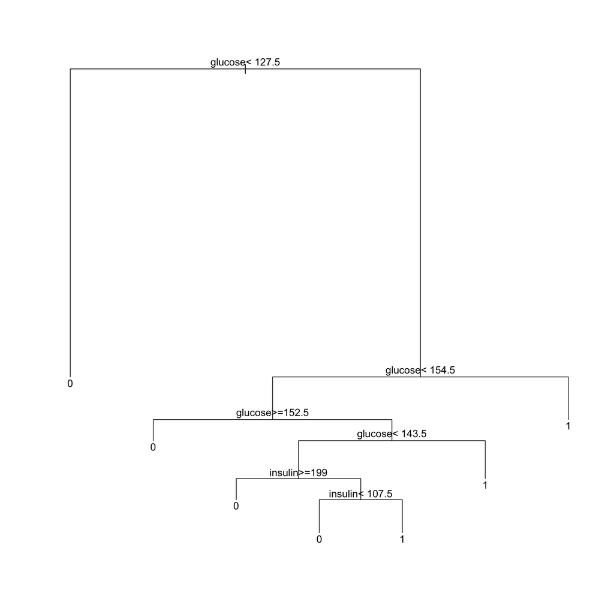

```r
plot(rtree)
text(rtree)
```

Two arguments: `params` and `control` control the way how the tree is build. For `params` use the `split` property to chose the measure that is optimized.

```r
rpart(test ~ insulin+glucose, data = pima,
    parms=list(split = "information"), method="class")
```

```
## n= 768
##
## node), split, n, loss, yval, (yprob)
##       * denotes terminal node
##
##   1) root 768 268 0 (0.6510417 0.3489583)
##     2) glucose< 127.5 485  94 0 (0.8061856 0.1938144) *
##     3) glucose>=127.5 283 109 1 (0.3851590 0.6148410)
##       6) glucose< 154.5 161  76 0 (0.5279503 0.4720497)
##        12) glucose>=152.5 8   1 0 (0.8750000 0.1250000) *
##        13) glucose< 152.5 153  75 0 (0.5098039 0.4901961)
##          26) glucose< 143.5 107  48 0 (0.5514019 0.4485981)
##            52) insulin>=199 15   4 0 (0.7333333 0.2666667) *
##            53) insulin< 199 92  44 0 (0.5217391 0.4782609)
##             106) insulin< 107.5 61  25 0 (0.5901639 0.4098361) *
##             107) insulin>=107.5 31  12 1 (0.3870968 0.6129032) *
##          27) glucose>=143.5 46  19 1 (0.4130435 0.5869565) *
##       7) glucose>=154.5 122  24 1 (0.1967213 0.8032787) *
```

```r
rpart(test ~ insulin+glucose, data = pima,
    parms=list(split = "gini"), method="class")
```

```
## n= 768
##
## node), split, n, loss, yval, (yprob)
##       * denotes terminal node
##
##   1) root 768 268 0 (0.6510417 0.3489583)
##     2) glucose< 127.5 485  94 0 (0.8061856 0.1938144) *
##     3) glucose>=127.5 283 109 1 (0.3851590 0.6148410)
##       6) glucose< 154.5 161  76 0 (0.5279503 0.4720497)
##        12) glucose>=152.5 8   1 0 (0.8750000 0.1250000) *
##        13) glucose< 152.5 153  75 0 (0.5098039 0.4901961)
##          26) glucose< 143.5 107  48 0 (0.5514019 0.4485981)
##            52) insulin>=199 15   4 0 (0.7333333 0.2666667) *
##            53) insulin< 199 92  44 0 (0.5217391 0.4782609)
##             106) insulin< 107.5 61  25 0 (0.5901639 0.4098361) *
##             107) insulin>=107.5 31  12 1 (0.3870968 0.6129032) *
##          27) glucose>=143.5 46  19 1 (0.4130435 0.5869565) *
##       7) glucose>=154.5 122  24 1 (0.1967213 0.8032787) *
```

For `control` set the object created by `rpart.control`, that describes stopping and splitting criteria. Following properties may be changed.

A very large tree

```r
tfit <- rpart(test ~ insulin+glucose, data = pima,
    parms=list(split = "gini"),
    control = rpart.control(cp=0))
tfit
```

```
## n= 768
##
## node), split, n, loss, yval, (yprob)
##       * denotes terminal node
##
##   1) root 768 268 0 (0.65104167 0.34895833)
##     2) glucose< 127.5 485  94 0 (0.80618557 0.19381443)
##       4) glucose< 99.5 197  16 0 (0.91878173 0.08121827) *
##       5) glucose>=99.5 288  78 0 (0.72916667 0.27083333)
##        10) insulin>=11 140  28 0 (0.80000000 0.20000000)
##          20) insulin< 113 63   6 0 (0.90476190 0.09523810) *
##          21) insulin>=113 77  22 0 (0.71428571 0.28571429)
##            42) glucose>=125.5 8   0 0 (1.00000000 0.00000000) *
##            43) glucose< 125.5 69  22 0 (0.68115942 0.31884058)
##              86) glucose< 117.5 43  10 0 (0.76744186 0.23255814) *
##              87) glucose>=117.5 26  12 0 (0.53846154 0.46153846)
##               174) glucose>=122.5 14   5 0 (0.64285714 0.35714286) *
##               175) glucose< 122.5 12   5 1 (0.41666667 0.58333333) *
##        11) insulin< 11 148  50 0 (0.66216216 0.33783784)
##          22) glucose< 122.5 129  39 0 (0.69767442 0.30232558)
##            44) glucose< 111.5 72  18 0 (0.75000000 0.25000000) *
##            45) glucose>=111.5 57  21 0 (0.63157895 0.36842105)
##              90) glucose>=121.5 7   1 0 (0.85714286 0.14285714) *
##              91) glucose< 121.5 50  20 0 (0.60000000 0.40000000)
##               182) glucose>=115.5 23   8 0 (0.65217391 0.34782609) *
##               183) glucose< 115.5 27  12 0 (0.55555556 0.44444444)
##                 366) glucose< 114.5 19   7 0 (0.63157895 0.36842105) *
##                 367) glucose>=114.5 8   3 1 (0.37500000 0.62500000) *
##          23) glucose>=122.5 19   8 1 (0.42105263 0.57894737) *
##     3) glucose>=127.5 283 109 1 (0.38515901 0.61484099)
##       6) glucose< 154.5 161  76 0 (0.52795031 0.47204969)
##        12) glucose>=152.5 8   1 0 (0.87500000 0.12500000) *
##        13) glucose< 152.5 153  75 0 (0.50980392 0.49019608)
##          26) glucose< 143.5 107  48 0 (0.55140187 0.44859813)
##            52) insulin>=199 15   4 0 (0.73333333 0.26666667) *
##            53) insulin< 199 92  44 0 (0.52173913 0.47826087)
##             106) insulin< 107.5 61  25 0 (0.59016393 0.40983607)
##               212) glucose>=136.5 25   8 0 (0.68000000 0.32000000) *
##               213) glucose< 136.5 36  17 0 (0.52777778 0.47222222)
##                 426) glucose< 129.5 10   3 0 (0.70000000 0.30000000) *
##                 427) glucose>=129.5 26  12 1 (0.46153846 0.53846154)
##                   854) glucose>=131.5 17   8 0 (0.52941176 0.47058824) *
##                   855) glucose< 131.5 9   3 1 (0.33333333 0.66666667) *
##             107) insulin>=107.5 31  12 1 (0.38709677 0.61290323)
##               214) glucose>=129.5 20  10 0 (0.50000000 0.50000000)
##                 428) insulin>=144.5 11   4 0 (0.63636364 0.36363636) *
##                 429) insulin< 144.5 9   3 1 (0.33333333 0.66666667) *
##               215) glucose< 129.5 11   2 1 (0.18181818 0.81818182) *
##          27) glucose>=143.5 46  19 1 (0.41304348 0.58695652)
##            54) insulin< 123 27  13 1 (0.48148148 0.51851852)
##             108) glucose>=146.5 15   7 0 (0.53333333 0.46666667) *
##             109) glucose< 146.5 12   5 1 (0.41666667 0.58333333) *
##            55) insulin>=123 19   6 1 (0.31578947 0.68421053) *
##       7) glucose>=154.5 122  24 1 (0.19672131 0.80327869)
##        14) glucose< 166.5 43  13 1 (0.30232558 0.69767442)
##          28) insulin>=250 8   3 0 (0.62500000 0.37500000) *
##          29) insulin< 250 35   8 1 (0.22857143 0.77142857) *
##        15) glucose>=166.5 79  11 1 (0.13924051 0.86075949) *
```

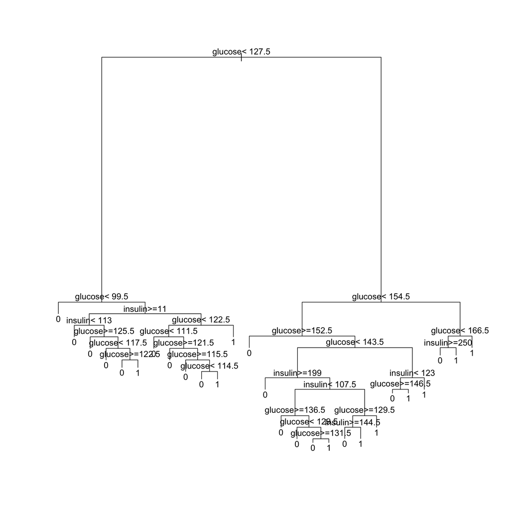

```r
plot(tfit)
text(tfit)
```

For deeper examination of a tree following functions are useful `printcp` and `plotcp`

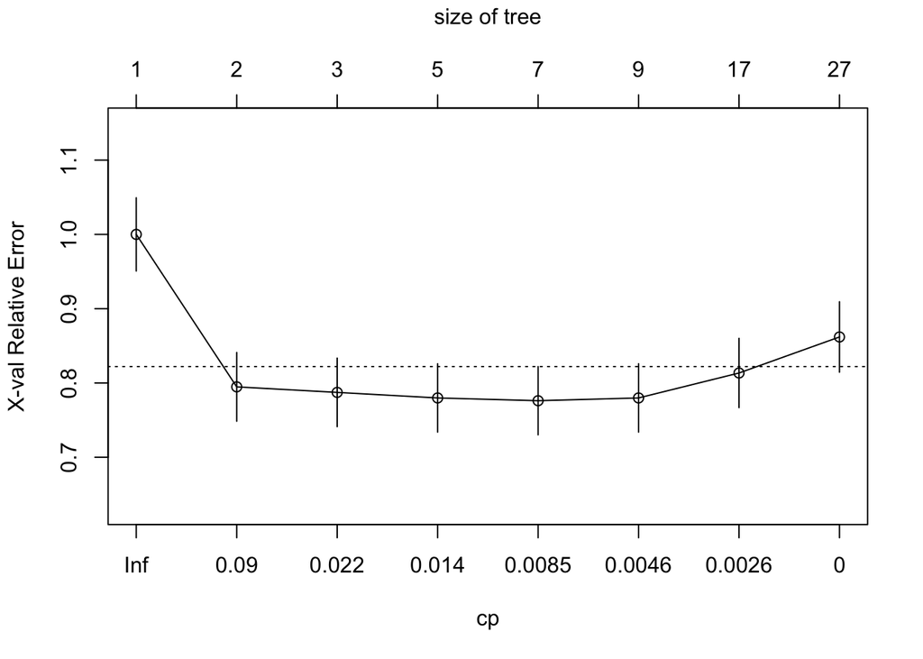

```r
plotcp(tfit)
```

```r
printcp(tfit)
```

```
##
## Classification tree:
## rpart(formula = test ~ insulin + glucose, data = pima, parms = list(split = "gini"),
##     control = rpart.control(cp = 0))
##
## Variables actually used in tree construction:
## [1] glucose insulin
##
## Root node error: 268/768 = 0.34896
##
## n= 768
##
##          CP nsplit rel error  xerror     xstd
## 1 0.2425373      0   1.00000 1.00000 0.049288
## 2 0.0335821      1   0.75746 0.79478 0.046294
## 3 0.0149254      2   0.72388 0.78731 0.046159
## 4 0.0130597      4   0.69403 0.77985 0.046022
## 5 0.0055970      6   0.66791 0.77612 0.045953
## 6 0.0037313      8   0.65672 0.77985 0.046022
## 7 0.0018657     16   0.62687 0.81343 0.046622
## 8 0.0000000     26   0.60821 0.86194 0.047422
```

```r
tfit <- rpart(test ~ insulin+glucose, data = pima,
    parms=list(split = "gini"),
    control = rpart.control(cp=0.1))

summary(tfit)
```

```
## Call:
## rpart(formula = test ~ insulin + glucose, data = pima, parms = list(split = "gini"),
##     control = rpart.control(cp = 0.1))
##   n= 768
##
##          CP nsplit rel error    xerror       xstd
## 1 0.2425373      0 1.0000000 1.0000000 0.04928752
## 2 0.1000000      1 0.7574627 0.8134328 0.04662235
##
## Variable importance
## glucose insulin
##      85      15
##
## Node number 1: 768 observations,    complexity param=0.2425373
##   predicted class=0  expected loss=0.3489583  P(node) =1
##     class counts:   500   268
##    probabilities: 0.651 0.349
##   left son=2 (485 obs) right son=3 (283 obs)
##   Primary splits:
##       glucose < 127.5 to the left,  improve=63.36011, (0 missing)
##       insulin < 121   to the left,  improve=13.33926, (0 missing)
##   Surrogate splits:
##       insulin < 121   to the left,  agree=0.697, adj=0.177, (0 split)
##
## Node number 2: 485 observations
##   predicted class=0  expected loss=0.1938144  P(node) =0.6315104
##     class counts:   391    94
##    probabilities: 0.806 0.194
##
## Node number 3: 283 observations
##   predicted class=1  expected loss=0.385159  P(node) =0.3684896
##     class counts:   109   174
##    probabilities: 0.385 0.615
```

Use additional parameters of `plot()` and `text()` functions to tune the way in which tree is presented (add additional information about group sizes).

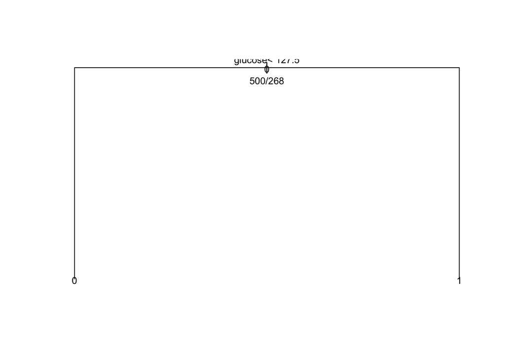

```r
plot(tfit, uniform=TRUE)
text(tfit, use.n=TRUE, all=TRUE, cex=.8)
```

Use the `prune()` function to prune / tune the tree.

```r
prune(tfit, cp=0.02)
```

```
## n= 768
##
## node), split, n, loss, yval, (yprob)
##       * denotes terminal node
##
## 1) root 768 268 0 (0.6510417 0.3489583)
##   2) glucose< 127.5 485  94 0 (0.8061856 0.1938144) *
##   3) glucose>=127.5 283 109 1 (0.3851590 0.6148410) *
```

### The party package

The `party` package has a better visualisation for a tree. It has also a more general approach to handle different classes of outcome variable. See http://statmath.wu-wien.ac.at/~zeileis/papers/Hothorn+Hornik+Zeileis-2006.pdf for more details.

The most important functions from party package are: `ctree`, `predict`, `print`, `plot`.

Use `ctree` to fit a tree. The syntax is similar to `rpart`.

```r
library(party)
pima$test <- factor(pima$test)

diabTree <- ctree(test ~ glucose+insulin, data = pima)

diabTree
```

```
##
##   Conditional inference tree with 4 terminal nodes
##
## Response:  test
## Inputs:  glucose, insulin
## Number of observations:  768
##
## 1) glucose <= 127; criterion = 1, statistic = 166.975
##   2) glucose <= 99; criterion = 1, statistic = 14.387
##     3)*  weights = 197
##   2) glucose > 99
##     4)*  weights = 288
## 1) glucose > 127
##   5) glucose <= 154; criterion = 1, statistic = 26.787
##     6)*  weights = 161
##   5) glucose > 154
##     7)*  weights = 122
```

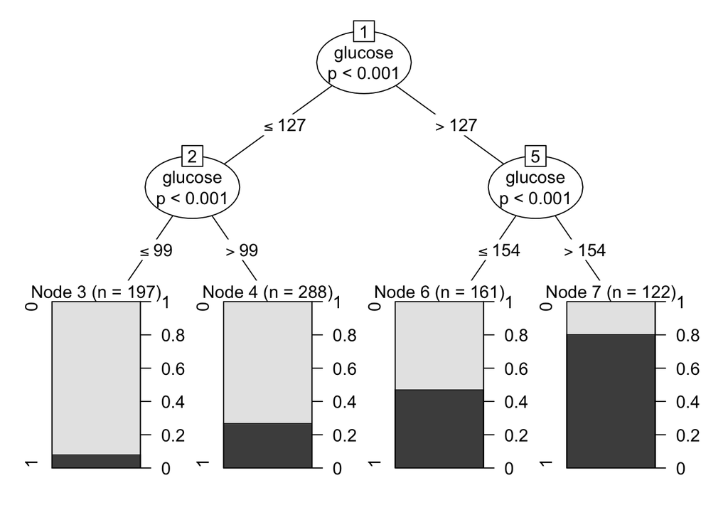

```r
plot(diabTree)
```

Use the `predict()` function to classify data based on fitting model.

```r
table(real = pima$test,
      predicted = predict(diabTree))
```

```
##     predicted
## real   0   1
##    0 476  24
##    1 170  98
```

Note that the `ctree` function works with continuous variables as well. Just as an example.

```r
tmp <- ctree(glucose ~ insulin+test, data = pima)
tmp
```

```
##
##   Conditional inference tree with 5 terminal nodes
##
## Response:  glucose
## Inputs:  insulin, test
## Number of observations:  768
##
## 1) test == {1}; criterion = 1, statistic = 166.975
##   2) insulin <= 220; criterion = 1, statistic = 18.24
##     3)*  weights = 230
##   2) insulin > 220
##     4)*  weights = 38
## 1) test == {0}
##   5) insulin <= 125; criterion = 1, statistic = 62.165
##     6)*  weights = 403
##   5) insulin > 125
##     7) insulin <= 335; criterion = 1, statistic = 21.028
##       8)*  weights = 86
##     7) insulin > 335
##       9)*  weights = 11
```

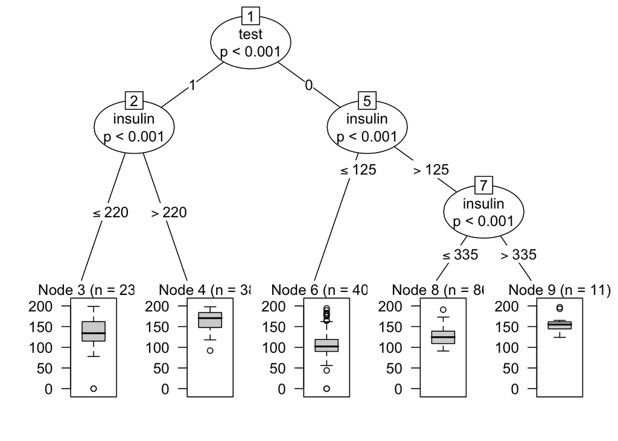

```r
plot(tmp)
```

### Control parameters

For `ctree` the default stop criteria is based on 1 - p-value for a selected test. P-values may be adjusted for number of applied tests (`testtype == "Bonferroni"`) or unjadusted (`testtype == "Univariate"`) or the test statistic may be used instead of p-value (`testtype == "Teststatistic"`).

Different test type are allowed. The parameter `testtype` based on general function for independence testing from package `coin`, namely `independence_test`.

Other optional control parameters may be set by `ctree_control` function. For example:

- mincriterion - split is made if p-value is smaller than 1-min criterion. For example `mincriterion=0.95` requires p-value smaller than 0.05.
- minsplit - split is created if sum of weights for both child nodes is greater than minsplit
- minbucket - minimum sum of weights in terminal node

For example, a much larger tree

```r
diabTree <- ctree(test ~ glucose+insulin, data = pima,
                    controls = ctree_control(mincriterion=0.1, minsplit=25, minbucket = 25))
diabTree
```

```
##
##   Conditional inference tree with 17 terminal nodes
##
## Response:  test
## Inputs:  glucose, insulin
## Number of observations:  768
##
## 1) glucose <= 127; criterion = 1, statistic = 166.975
##   2) glucose <= 99; criterion = 1, statistic = 14.387
##     3) insulin <= 87; criterion = 0.914, statistic = 4.067
##       4) glucose <= 95; criterion = 0.944, statistic = 4.798
##         5) glucose <= 89; criterion = 0.914, statistic = 4.061
##           6) glucose <= 84; criterion = 0.994, statistic = 8.783
##             7) glucose <= 79; criterion = 0.988, statistic = 7.511
##               8)*  weights = 40
##             7) glucose > 79
##               9)*  weights = 26
##           6) glucose > 84
##             10)*  weights = 30
##         5) glucose > 89
##           11)*  weights = 44
##       4) glucose > 95
##         12)*  weights = 29
##     3) insulin > 87
##       13)*  weights = 28
##   2) glucose > 99
##     14) glucose <= 111; criterion = 0.706, statistic = 1.977
##       15)*  weights = 137
##     14) glucose > 111
##       16) insulin <= 0; criterion = 0.545, statistic = 1.261
##         17) glucose <= 120; criterion = 0.213, statistic = 0.378
##           18)*  weights = 48
##         17) glucose > 120
##           19)*  weights = 28
##       16) insulin > 0
##         20) insulin <= 140; criterion = 0.946, statistic = 4.88
##           21)*  weights = 40
##         20) insulin > 140
##           22)*  weights = 35
## 1) glucose > 127
##   23) glucose <= 154; criterion = 1, statistic = 26.787
##     24) insulin <= 182; criterion = 0.122, statistic = 0.205
##       25) insulin <= 122; criterion = 0.564, statistic = 1.328
##         26)*  weights = 94
##       25) insulin > 122
##         27)*  weights = 34
##     24) insulin > 182
##       28)*  weights = 33
##   23) glucose > 154
##     29) glucose <= 166; criterion = 0.479, statistic = 1.038
##       30)*  weights = 43
##     29) glucose > 166
##       31) glucose <= 178; criterion = 0.536, statistic = 1.227
##         32)*  weights = 28
##       31) glucose > 178
##         33)*  weights = 51
```

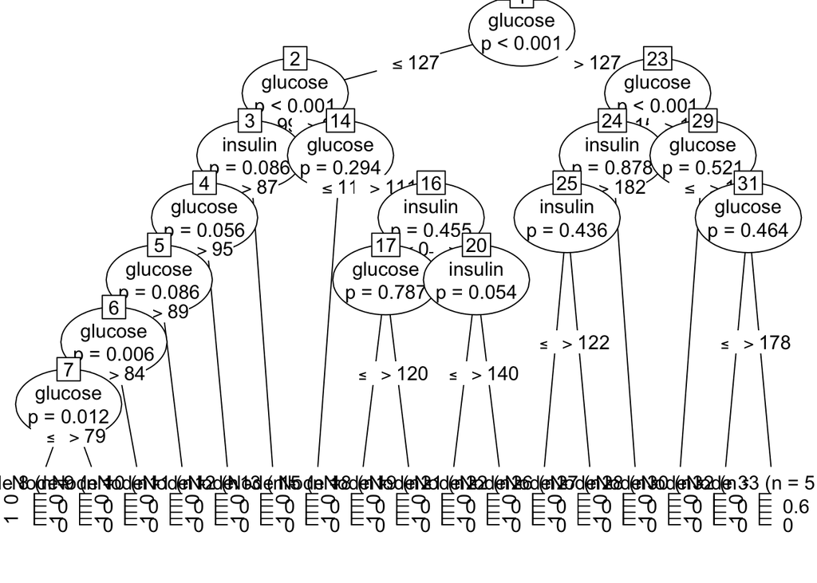

```r
plot(diabTree)
```

## Summary

Pros

- White box model
- Simple to interpret
- No need for variable normalisation (use cutoffs)
- Handle numerical and categorical data

Cons

- Overfits

# Overview of Random Forests

Very good source of information about Random Forests

https://www.stat.berkeley.edu/~breiman/RandomForests/cc_home.htm

Key features * Forest is composed out of trees, final results are calculated by voting (each tree has a single vote) * Each tree is build based on a bootstrap sample (sample on the same size draw with replacement) * Each tree is build based on a subset of m << p variables * Each tree is grown to be the largest possible (a single tree will be over fitted)

Note that value m plays important role. Small m - reduced correlation between trees (better - lower error rate) and reduces strength of a tree (higher error rate). So there is something like ‘optimal m’. Find with the use of OOB.

### Pros and cons

Pros

- Very good accuracy
- Can handle thousands of variables
- Gives estimates of variable importance

Cons

- A black box model

## Important concepts

### OOB (out-of-bag) error rate

For each tree around 1/3 of observations is not used for building the tree. Thus they may be used for assessment of tree performance.

### Proximities

For each pair of observations proximity is calculated as the chance that this pair falls to the same terminal node.

### Variable importance

For every tree one can calculate the added value in performance, i.e. how the tree is better than a random classifier. In order to get raw variable importance for a given variable sum up scores for all trees with given variable.

### Gini importance

As above but sum the improvements in gini coefficient.

## Implementations in R

The most widely know is in the `randomForest` package.

```r
library(randomForest)
ffit <- randomForest(test ~ .,   data=pima, importance = TRUE)
print(ffit)
```

```
##
## Call:
##  randomForest(formula = test ~ ., data = pima, importance = TRUE)
##                Type of random forest: classification
##                      Number of trees: 500
## No. of variables tried at each split: 2
##
##         OOB estimate of  error rate: 24.22%
## Confusion matrix:
##     0   1 class.error
## 0 427  73   0.1460000
## 1 113 155   0.4216418
```

### Importance scores for variables.

```r
importance(ffit)
```

```
##                   0          1 MeanDecreaseAccuracy MeanDecreaseGini
## pregnant  14.813048  0.7704716            13.474689         28.85815
## glucose   35.108960 39.2075787            49.667818         88.20936
## diastolic  5.998338 -1.4506447             3.617939         30.77518
## triceps    4.601645  3.2322750             5.724626         23.57918
## insulin   10.097365  5.0572703            11.341249         25.95088
## bmi       16.250615 20.1580217            25.822414         58.54479
## diabetes   5.762416  4.3200416             7.301237         43.62115
## age       19.416819  9.1036249            22.556137         47.50439
```

### Importance plot for variables.

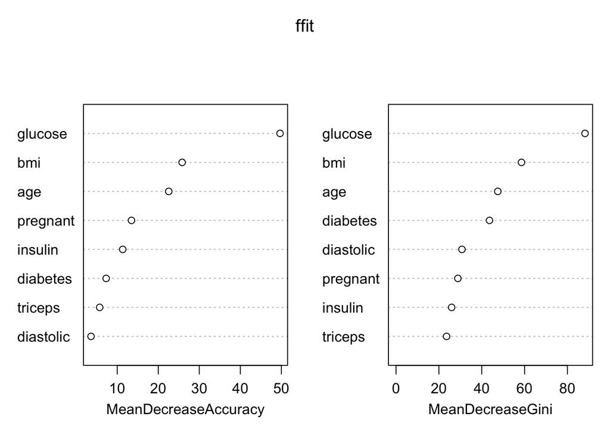

```r
varImpPlot(ffit)
```

### Predictions

```r
head(predict(ffit, type="prob"))
```

```
##           0           1
## 1 0.3005464 0.699453552
## 2 0.8606965 0.139303483
## 3 0.4535519 0.546448087
## 4 0.9947090 0.005291005
## 5 0.2568306 0.743169399
## 6 0.8972973 0.102702703
```

# ROC (Receiver Operating Characteristics)

Classifiers that calculate scores / probabilities may be examined with the use of so called ROC. Let’s see an simple example for the trained random forest.

```r
prob <- predict(ffit, type="prob")[,2]

library(ROCR)
```

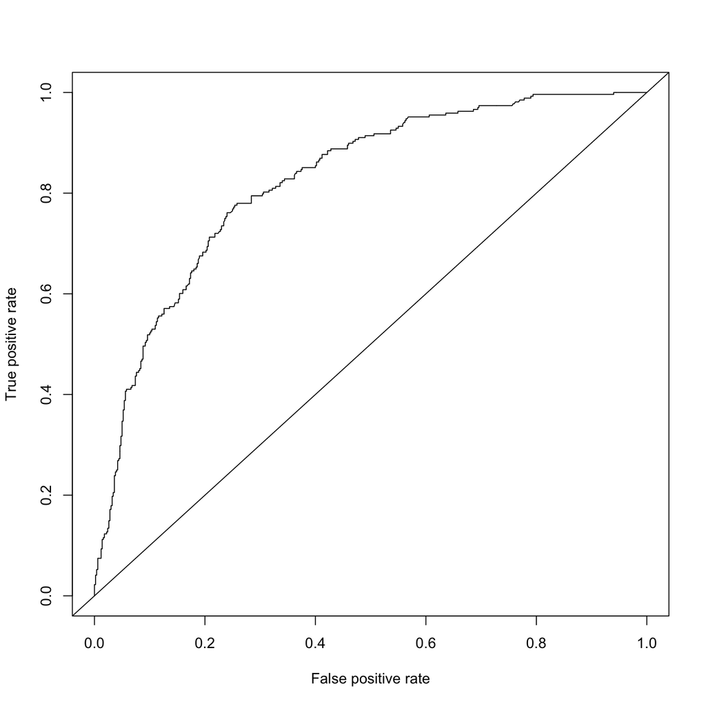

```r
fit.pred = prediction(prob, pima$test)
fit.perf = performance(fit.pred,"tpr","fpr")
plot(fit.perf)
abline(a=0,b=1)
```

# The Homework

Download the dataset `adult` (find more about this dataset here: http://archive.ics.uci.edu/ml/machine-learning-databases/adult/). Train a decision tree and a random forest. Compare performance of both methods.

Take some time to find variables that are not used by anyone else (sumbissions with same set of variables will not be scored).

```r
data = read.table("http://archive.ics.uci.edu/ml/machine-learning-databases/adult/adult.data",
        sep=",",header=F,col.names=c("age", "type_employer", "fnlwgt", "education",
                "education_num","marital", "occupation", "relationship", "race","sex",
                "capital_gain", "capital_loss", "hr_per_week","country", "income"),
        fill=FALSE,strip.white=T)
head(data,3)
```

```
##   age    type_employer fnlwgt education education_num            marital
## 1  39        State-gov  77516 Bachelors            13      Never-married
## 2  50 Self-emp-not-inc  83311 Bachelors            13 Married-civ-spouse
## 3  38          Private 215646   HS-grad             9           Divorced
##          occupation  relationship  race  sex capital_gain capital_loss
## 1      Adm-clerical Not-in-family White Male         2174            0
## 2   Exec-managerial       Husband White Male            0            0
## 3 Handlers-cleaners Not-in-family White Male            0            0
##   hr_per_week       country income
## 1          40 United-States  <=50K
## 2          13 United-States  <=50K
## 3          40 United-States  <=50K
```